# Lesson 8

### Welcome

Notes:

### Scatterplot Review

```r
library('ggplot2')
data(diamonds)
```

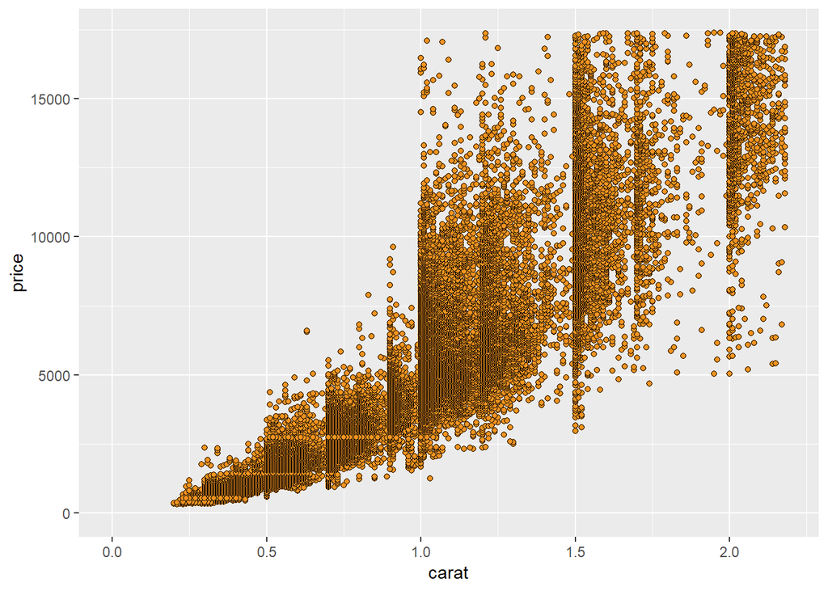

```r
ggplot(diamonds, aes(carat, price)) +
  scale_x_continuous(lim = c(0, quantile(diamonds$carat, 0.99))) +
  scale_y_continuous(lim = c(0, quantile(diamonds$price, 0.99))) +
  geom_point(fill = I('#F79420'), color = I('black'), shape = 21)
```

### Price and Carat Relationship

Response:

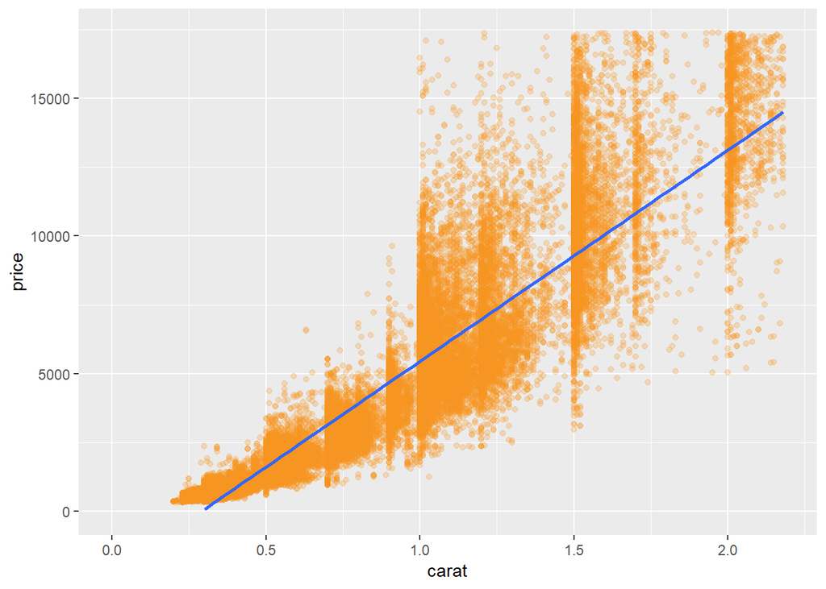

```r
ggplot(diamonds, aes(carat, price)) +
  geom_point(color = '#F79420', alpha = 1/4) +
  stat_smooth(method = 'lm') +
  scale_x_continuous(lim = c(0, quantile(diamonds$carat, 0.99))) +
  scale_y_continuous(lim = c(0, quantile(diamonds$price, 0.99)))
```

***

### Frances Gerety

Notes:

### The Rise of Diamonds

Notes:

### ggpairs Function

Notes:

```r
# install these if necessary
# install.packages('GGally')
# install.packages('scales')
# install.packages('memisc')
# install.packages('lattice')
# install.packages('MASS')
# install.packages('car')
# install.packages('reshape')
# install.packages('plyr')

# load the ggplot graphics package and the others
library(ggplot2)
library(GGally)
library(scales)
library(memisc)
library(grid)
library(gridExtra)
```

# sample 10,000 diamonds from the data set

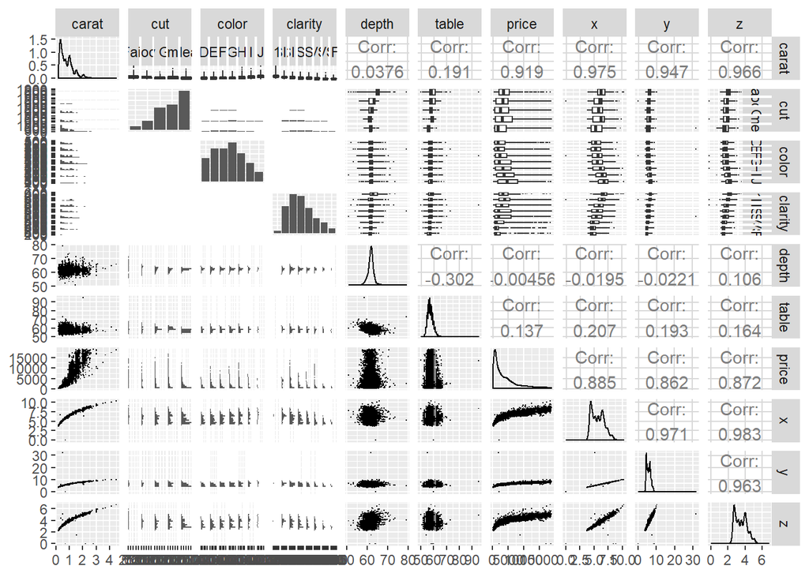

```r
set.seed(20022012)
diamond_samp <- diamonds[sample(1:length(diamonds$price), 10000), ]
# ggpairs(diamond_samp, params = c(shape = I('.'), outlier.shape = I('.')))
ggpairs(diamond_samp,
        lower = list(continuous = wrap("points", shape = I('.'))),
        upper = list(combo = wrap("box", outlier.shape = I('.'))))
```

What are some things you notice in the ggpairs output? Response:

### The Demand of Diamonds

Notes:

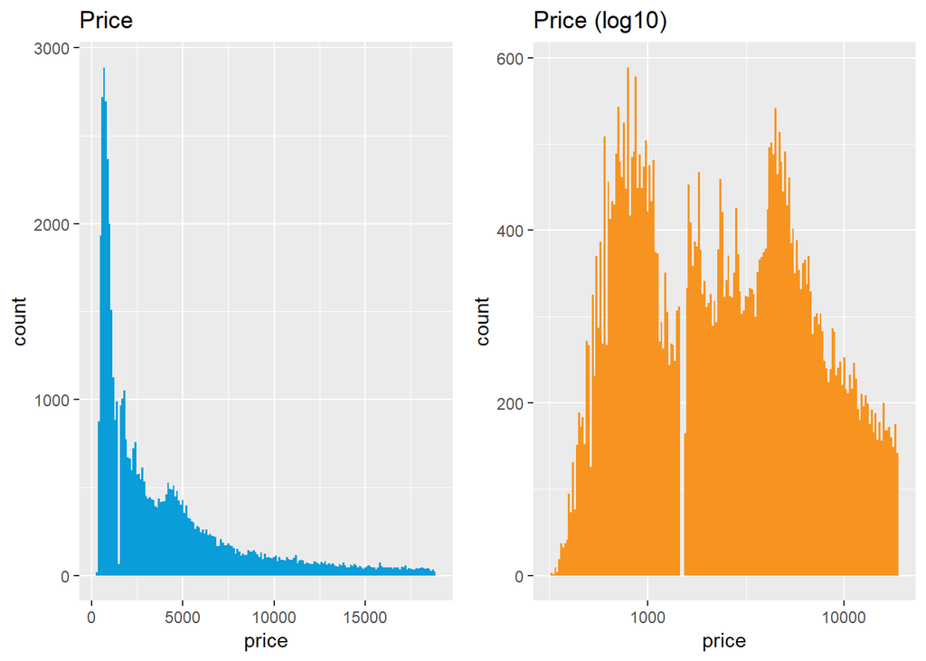

```r
plot1 <- ggplot(diamonds, aes(price)) +
  ggtitle('Price') +
  geom_histogram(binwidth = 100, fill = '#099DD9')
plot2 <- ggplot(diamonds, aes(price)) +
  ggtitle('Price (log10)') +
  geom_histogram(binwidth = 0.01 , fill = '#F79420') +
  scale_x_log10()
grid.arrange(plot1, plot2, ncol = 2)
```

### Connecting Demand and Price Distributions

Notes:

### Scatterplot Transformation

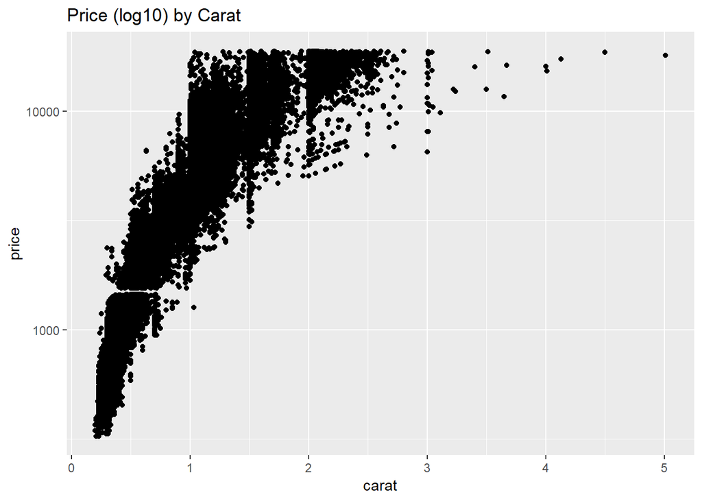

```r
qplot(carat, price, data = diamonds) +
  scale_y_continuous(trans = log10_trans()) +
  ggtitle('Price (log10) by Carat')
```

### Create a new function to transform the carat variable

```r
cuberoot_trans = function() trans_new('cuberoot', transform = function(x) x^(1/3),
                                      inverse = function(x) x^3)
```

#### Use the cuberoot_trans function

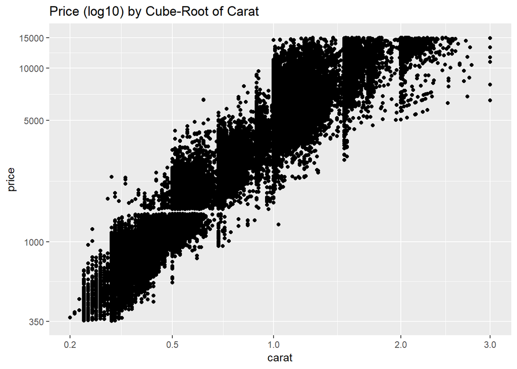

```r
ggplot(aes(carat, price), data = diamonds) +
  geom_point() +
  scale_x_continuous(trans = cuberoot_trans(), limits = c(0.2, 3),
                     breaks = c(0.2, 0.5, 1, 2, 3)) +
  scale_y_continuous(trans = log10_trans(), limits = c(350, 15000),
                     breaks = c(350, 1000, 5000, 10000, 15000)) +
  ggtitle('Price (log10) by Cube-Root of Carat')
```

### Overplotting Revisited

```r
head(sort(table(diamonds$carat), decreasing = T))
```

```
##
##  0.3 0.31 1.01  0.7 0.32    1
## 2604 2249 2242 1981 1840 1558
```

```r
head(sort(table(diamonds$price), decreasing = T))
```

```
##
## 605 802 625 828 776 698
## 132 127 126 125 124 121
```

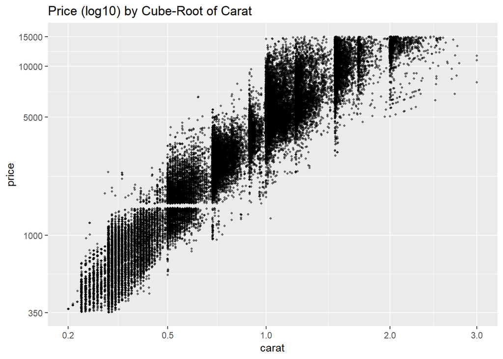

```r
ggplot(aes(carat, price), data = diamonds) +
  geom_point(alpha = .5, size = .75, position = 'jitter') +
  scale_x_continuous(trans = cuberoot_trans(), limits = c(0.2, 3),
                     breaks = c(0.2, 0.5, 1, 2, 3)) +
  scale_y_continuous(trans = log10_trans(), limits = c(350, 15000),
                     breaks = c(350, 1000, 5000, 10000, 15000)) +
  ggtitle('Price (log10) by Cube-Root of Carat')
```

### Other Qualitative Factors

Notes:

### Price vs. Carat and Clarity

Alter the code below.

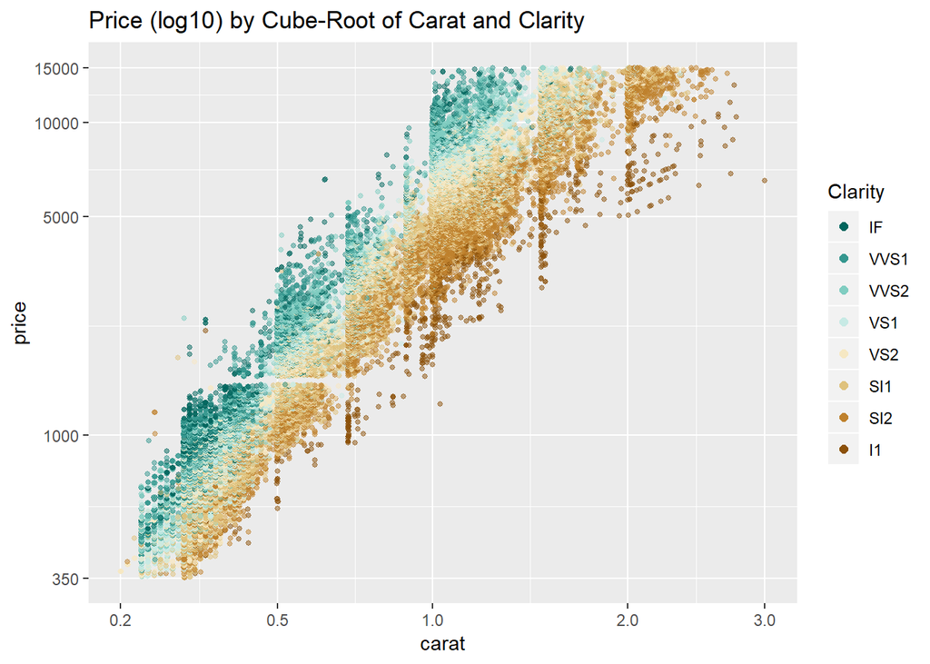

```r
# install and load the RColorBrewer package
library("RColorBrewer", lib.loc="~/Anaconda3/envs/py37pipped/Lib/R/library")

ggplot(aes(x = carat, y = price, colour = clarity), data = diamonds) +
  geom_point(alpha = 0.5, size = 1, position = 'jitter') +
  scale_color_brewer(type = 'div',
    guide = guide_legend(title = 'Clarity', reverse = T,
    override.aes = list(alpha = 1, size = 2))) +
  scale_x_continuous(trans = cuberoot_trans(), limits = c(0.2, 3),
    breaks = c(0.2, 0.5, 1, 2, 3)) +
  scale_y_continuous(trans = log10_trans(), limits = c(350, 15000),
    breaks = c(350, 1000, 5000, 10000, 15000)) +
  ggtitle('Price (log10) by Cube-Root of Carat and Clarity')
```

### Clarity and Price

Response:

### Price vs. Carat and Cut

Alter the code below.

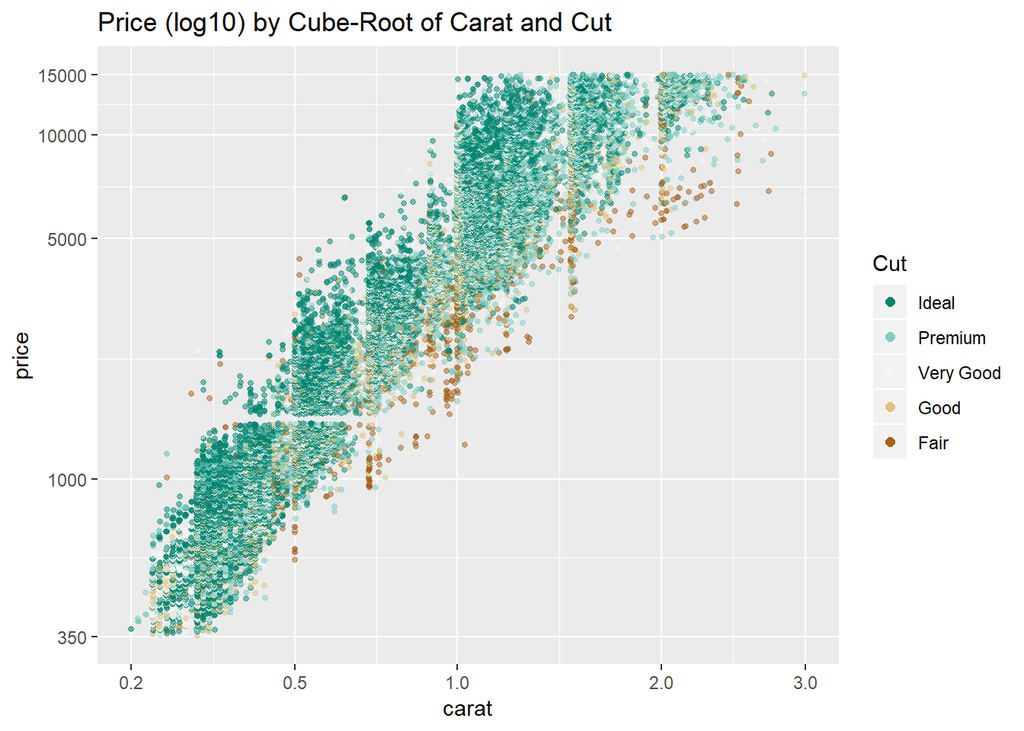

```r
ggplot(aes(x = carat, y = price, color = cut), data = diamonds) +
  geom_point(alpha = 0.5, size = 1, position = 'jitter') +
  scale_color_brewer(type = 'div',
                     guide = guide_legend(title = 'Cut', reverse = T,
                                          override.aes = list(alpha = 1,
                                                              size = 2))) +
  scale_x_continuous(trans = cuberoot_trans(), limits = c(0.2, 3),
                     breaks = c(0.2, 0.5, 1, 2, 3)) +
  scale_y_continuous(trans = log10_trans(), limits = c(350, 15000),
                     breaks = c(350, 1000, 5000, 10000, 15000)) +
  ggtitle('Price (log10) by Cube-Root of Carat and Cut')
```

### Cut and Price

Response:

### Price vs. Carat and Color

Alter the code below.

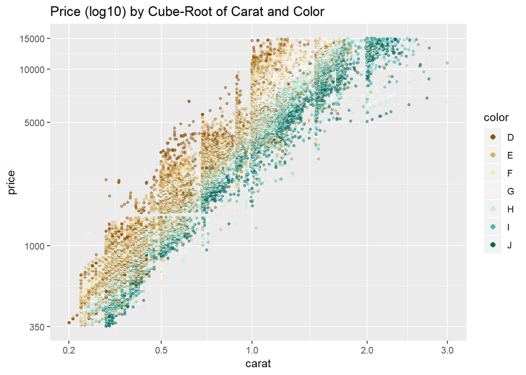

```r
ggplot(aes(x = carat, y = price, color = color), data = diamonds) +
  geom_point(alpha = 0.5, size = 1, position = 'jitter') +
  scale_color_brewer(type = 'div',
                     guide = guide_legend(title = 'color', reverse = FALSE,
                                          override.aes = list(alpha = 1,
                                                              size = 2))) +
  scale_x_continuous(trans = cuberoot_trans(), limits = c(0.2, 3),
                     breaks = c(0.2, 0.5, 1, 2, 3)) +
  scale_y_continuous(trans = log10_trans(), limits = c(350, 15000),
                     breaks = c(350, 1000, 5000, 10000, 15000)) +
  ggtitle('Price (log10) by Cube-Root of Carat and Color')
```

### Color and Price

Response:

### Linear Models in R

Notes:

Response:

### Building the Linear Model

Notes:

```r
# 'I() stands for 'as-is'.  will transform before using in regression
m1 <- lm(I(log(price)) ~ I(carat^(1/3)), data = diamonds)
m2 <- update(m1, ~ . + carat)
m3 <- update(m2, ~ . + cut)
m4 <- update(m3, ~ . + color)
m5 <- update(m4, ~ . + clarity)
mtable(m1, m2, m3, m4, m5)
```

```
##
## Calls:
## m1: lm(formula = I(log(price)) ~ I(carat^(1/3)), data = diamonds)
## m2: lm(formula = I(log(price)) ~ I(carat^(1/3)) + carat, data = diamonds)
## m3: lm(formula = I(log(price)) ~ I(carat^(1/3)) + carat + cut, data = diamonds)
## m4: lm(formula = I(log(price)) ~ I(carat^(1/3)) + carat + cut + color,
##     data = diamonds)
## m5: lm(formula = I(log(price)) ~ I(carat^(1/3)) + carat + cut + color +
##     clarity, data = diamonds)
##
## ========================================================================================
##                        m1            m2            m3            m4            m5
## ----------------------------------------------------------------------------------------
##   (Intercept)         2.821***      1.039***      0.874***      0.932***      0.415***
##                      (0.006)       (0.019)       (0.019)       (0.017)       (0.010)
##   I(carat^(1/3))      5.558***      8.568***      8.703***      8.438***      9.144***
##                      (0.007)       (0.032)       (0.031)       (0.028)       (0.016)
##   carat                            -1.137***     -1.163***     -0.992***     -1.093***
##                                    (0.012)       (0.011)       (0.010)       (0.006)
##   cut: .L                                         0.224***      0.224***      0.120***
##                                                  (0.004)       (0.004)       (0.002)
##   cut: .Q                                        -0.062***     -0.062***     -0.031***
##                                                  (0.004)       (0.003)       (0.002)
##   cut: .C                                         0.051***      0.052***      0.014***
##                                                  (0.003)       (0.003)       (0.002)
##   cut: ^4                                         0.018***      0.018***     -0.002
##                                                  (0.003)       (0.002)       (0.001)
##   color: .L                                                    -0.373***     -0.441***
##                                                                (0.003)       (0.002)
##   color: .Q                                                    -0.129***     -0.093***
##                                                                (0.003)       (0.002)
##   color: .C                                                     0.001        -0.013***
##                                                                (0.003)       (0.002)
##   color: ^4                                                     0.029***      0.012***
##                                                                (0.003)       (0.002)
##   color: ^5                                                    -0.016***     -0.003*
##                                                                (0.003)       (0.001)
##   color: ^6                                                    -0.023***      0.001
##                                                                (0.002)       (0.001)
##   clarity: .L                                                                 0.907***
##                                                                              (0.003)
##   clarity: .Q                                                                -0.240***
##                                                                              (0.003)
##   clarity: .C                                                                 0.131***
##                                                                              (0.003)
##   clarity: ^4                                                                -0.063***
##                                                                              (0.002)
##   clarity: ^5                                                                 0.026***
##                                                                              (0.002)
##   clarity: ^6                                                                -0.002
##                                                                              (0.002)
##   clarity: ^7                                                                 0.032***
##                                                                              (0.001)
## ----------------------------------------------------------------------------------------
##   R-squared           0.924         0.935         0.939         0.951         0.984
##   N               53940         53940         53940         53940         53940
## ========================================================================================
##   Significance: *** = p < 0.001; ** = p < 0.01; * = p < 0.05
```

Notice how adding cut to our model does not help explain much of the variance in the price of diamonds. This fits with out exploration earlier.

### Model Problems

Video Notes:

Research: (Take some time to come up with 2-4 problems for the model) (You should 10-20 min on this)

Response:

### A Bigger, Better Data Set

Notes:

```r
library("bitops", lib.loc="~/Anaconda3/envs/py37pipped/Lib/R/library")
library("RCurl", lib.loc="~/Anaconda3/envs/py37pipped/Lib/R/library")
# Rcurl needs libcurl, not available on windows(easily)
# diamondsurl = getBinaryURL("https://raw.github.com/solomonm/diamonds-data/master/BigDiamonds.Rda")
# load(rawConnection(diamondsurl))
load("BigDiamonds.rda")
```

The code used to obtain the data is available here: https://github.com/solomonm/diamonds-data

## Building a Model Using the Big Diamonds Data Set

Notes:

```r
diamondsbig$logprice = log(diamondsbig$price)
m1 <- lm(I(log(price)) ~ I(carat^(1/3)),
         data = diamondsbig[diamondsbig$price < 10000 &
                              diamondsbig$cert == "GIA", ])
m2 <- update(m1, ~ . + carat)
m3 <- update(m2, ~ . + cut)
m4 <- update(m3, ~ . + color)
m5 <- update(m4, ~ . + clarity)
mtable(m1, m2, m3, m4, m5)
```

```
##
## Calls:
## m1: lm(formula = I(log(price)) ~ I(carat^(1/3)), data = diamondsbig[diamondsbig$price <
##     10000 & diamondsbig$cert == "GIA", ])
## m2: lm(formula = I(log(price)) ~ I(carat^(1/3)) + carat, data = diamondsbig[diamondsbig$price <
##     10000 & diamondsbig$cert == "GIA", ])
## m3: lm(formula = I(log(price)) ~ I(carat^(1/3)) + carat + cut, data = diamondsbig[diamondsbig$price <
##     10000 & diamondsbig$cert == "GIA", ])
## m4: lm(formula = I(log(price)) ~ I(carat^(1/3)) + carat + cut + color,
##     data = diamondsbig[diamondsbig$price < 10000 & diamondsbig$cert ==
##         "GIA", ])
## m5: lm(formula = I(log(price)) ~ I(carat^(1/3)) + carat + cut + color +
##     clarity, data = diamondsbig[diamondsbig$price < 10000 & diamondsbig$cert ==
##     "GIA", ])
##
## =============================================================================================
##                        m1             m2             m3             m4             m5
## ---------------------------------------------------------------------------------------------
##   (Intercept)          2.671***       1.333***       0.949***       0.529***      -0.464***
##                       (0.003)        (0.012)        (0.012)        (0.010)        (0.009)
##   I(carat^(1/3))       5.839***       8.243***       8.633***       8.110***       8.320***
##                       (0.004)        (0.022)        (0.021)        (0.017)        (0.012)
##   carat                              -1.061***      -1.223***      -0.782***      -0.763***
##                                      (0.009)        (0.009)        (0.007)        (0.005)
##   cut: V.Good                                        0.120***       0.090***       0.071***
##                                                     (0.002)        (0.001)        (0.001)
##   cut: Ideal                                         0.211***       0.181***       0.131***
##                                                     (0.002)        (0.001)        (0.001)
##   color: K/L                                                        0.123***       0.117***
##                                                                    (0.004)        (0.003)
##   color: J/L                                                        0.312***       0.318***
##                                                                    (0.003)        (0.002)
##   color: I/L                                                        0.451***       0.469***
##                                                                    (0.003)        (0.002)
##   color: H/L                                                        0.569***       0.602***
##                                                                    (0.003)        (0.002)
##   color: G/L                                                        0.633***       0.665***
##                                                                    (0.003)        (0.002)
##   color: F/L                                                        0.687***       0.723***
##                                                                    (0.003)        (0.002)
```

[output cut: 10 more lines]

```
##   clarity: VS2                                                                     0.836***
##                                                                                   (0.006)
##   clarity: VS1                                                                     0.891***
##                                                                                   (0.006)
##   clarity: VVS2                                                                    0.935***
##                                                                                   (0.006)
##   clarity: VVS1                                                                    0.995***
##                                                                                   (0.006)
##   clarity: IF                                                                      1.052***
##                                                                                   (0.006)
## ---------------------------------------------------------------------------------------------
##   R-squared            0.888          0.892          0.899          0.937          0.969
##   N               338946         338946         338946         338946         338946
## =============================================================================================
##   Significance: *** = p < 0.001; ** = p < 0.01; * = p < 0.05
```

## Predictions

Example Diamond from BlueNile: Round 1.00 Very Good I VS1 $5,601

```r
#Be sure you’ve loaded the library memisc and have m5 saved as an object in your workspace.
thisDiamond = data.frame(carat = 1.00, cut = "V.Good",
                         color = "I", clarity="VS1")
modelEstimate = predict(m5, newdata = thisDiamond,
                        interval="prediction", level = .95)
```

Evaluate how well the model predicts the BlueNile diamond’s price. Think about the fitted point estimate as well as the 95% CI.

## Final Thoughts

Notes:

Click **KnitHTML** to see all of your hard work and to have an html page of this lesson, your answers, and your notes!